# Part I - (Ford GoBike System Data)

## Introduction

> This data set includes information about individual rides made in a bike-sharing system covering the greater San Francisco Bay area. The objective of this project is to draw insights from the dataset using visualization

## Preliminary Wrangling

```python
# import all packages and set plots to be embedded inline
import numpy as np
import pandas as pd
import matplotlib.pyplot as plt
import seaborn as sb
import re
import math
from numpy import mean

%matplotlib inline

# # suppress warnings from final output
import warnings
warnings.simplefilter("ignore")
```

```python
# Loading in my dataset
df = pd.read_csv('201902-fordgobike-tripdata.csv')
df.head()
```

|  | duration_sec | start_time | end_time | start_station_id | start_station_name | start_station_latitude | start_station_longitude | end_station_id | end_station_name | end_station_latitude | end_station_longitude | bike_id | user_type | member_birth_year | member_gender | bike_share_for_all_trip |
| --- | --- | --- | --- | --- | --- | --- | --- | --- | --- | --- | --- | --- | --- | --- | --- | --- |
| 0 | 52185 | 2019-02-28 17:32:10.1450 | 2019-03-01 08:01:55.9750 | 21.0 | Montgomery St BART Station (Market St at 2nd St) | 37.789625 | -122.400811 | 13.0 | Commercial St at Montgomery St | 37.794231 | -122.402923 | 4902 | Customer | 1984.0 | Male | No |
| 1 | 42521 | 2019-02-28 18:53:21.7890 | 2019-03-01 06:42:03.0560 | 23.0 | The Embarcadero at Steuart St | 37.791464 | -122.391034 | 81.0 | Berry St at 4th St | 37.775880 | -122.393170 | 2535 | Customer | NaN | NaN | No |
| 2 | 61854 | 2019-02-28 12:13:13.2180 | 2019-03-01 05:24:08.1460 | 86.0 | Market St at Dolores St | 37.769305 | -122.426826 | 3.0 | Powell St BART Station (Market St at 4th St) | 37.786375 | -122.404904 | 5905 | Customer | 1972.0 | Male | No |
| 3 | 36490 | 2019-02-28 17:54:26.0100 | 2019-03-01 04:02:36.8420 | 375.0 | Grove St at Masonic Ave | 37.774836 | -122.446546 | 70.0 | Central Ave at Fell St | 37.773311 | -122.444293 | 6638 | Subscriber | 1989.0 | Other | No |
| 4 | 1585 | 2019-02-28 23:54:18.5490 | 2019-03-01 00:20:44.0740 | 7.0 | Frank H Ogawa Plaza | 37.804562 | -122.271738 | 222.0 | 10th Ave at E 15th St | 37.792714 | -122.248780 | 4898 | Subscriber | 1974.0 | Male | Yes |

### Some Data Wrangling to clean the dataset and make it fit for analysis

First a general overview of the dataset

```python
# Check for the number of rows and columns in the dataset
print(df.shape)
print('The dataset has ' + str(df.shape[0]) + ' rows' + ' and ' + str(df.shape[1]) + ' columns')
```

```
(183412, 16)
The dataset has 183412 rows and 16 columns
```

```python
df.info()
```

```
<class 'pandas.core.frame.DataFrame'>
RangeIndex: 183412 entries, 0 to 183411
Data columns (total 16 columns):
 #   Column                   Non-Null Count   Dtype
---  ------                   --------------   -----
 0   duration_sec             183412 non-null  int64
 1   start_time               183412 non-null  object
 2   end_time                 183412 non-null  object
 3   start_station_id         183215 non-null  float64
 4   start_station_name       183215 non-null  object
 5   start_station_latitude   183412 non-null  float64
 6   start_station_longitude  183412 non-null  float64
 7   end_station_id           183215 non-null  float64
 8   end_station_name         183215 non-null  object
 9   end_station_latitude     183412 non-null  float64
 10  end_station_longitude    183412 non-null  float64
 11  bike_id                  183412 non-null  int64
 12  user_type                183412 non-null  object
 13  member_birth_year        175147 non-null  float64
 14  member_gender            175147 non-null  object
 15  bike_share_for_all_trip  183412 non-null  object
dtypes: float64(7), int64(2), object(7)
memory usage: 22.4+ MB
```

```python
df['start_station_id'].nunique()
```

```
329
```

- Columns such as member_birth_year and member_gender have missing values as indicated by the number of no_null values, these rows will be dropped
- Info on start and end station would all be dropped except fot the station name
- Start and end date should be datetime datatype, also will be better represented as catogorical variable

```python
df.isnull().sum()
```

```
duration_sec                  0
start_time                    0
end_time                      0
start_station_id            197
start_station_name          197
start_station_latitude        0
start_station_longitude       0
end_station_id              197
end_station_name            197
end_station_latitude          0
end_station_longitude         0
bike_id                       0
user_type                     0
member_birth_year          8265
member_gender              8265
bike_share_for_all_trip       0
dtype: int64
```

```python
# Remove all rows that null values
df1 = df.dropna()

# Checking for the number of rows left
df1.shape
```

```
(174952, 16)
```

```python
df2 = df1[['duration_sec','start_time','end_time','start_station_name','end_station_name'
          ,'bike_id','user_type','member_birth_year','member_gender','bike_share_for_all_trip']]
df2.head(2)
```

|  | duration_sec | start_time | end_time | start_station_name | end_station_name | bike_id | user_type | member_birth_year | member_gender | bike_share_for_all_trip |
| --- | --- | --- | --- | --- | --- | --- | --- | --- | --- | --- |
| 0 | 52185 | 2019-02-28 17:32:10.1450 | 2019-03-01 08:01:55.9750 | Montgomery St BART Station (Market St at 2nd St) | Commercial St at Montgomery St | 4902 | Customer | 1984.0 | Male | No |
| 2 | 61854 | 2019-02-28 12:13:13.2180 | 2019-03-01 05:24:08.1460 | Market St at Dolores St | Powell St BART Station (Market St at 4th St) | 5905 | Customer | 1972.0 | Male | No |

Checking for duplicated rows in the dataset

```python
df2.duplicated().sum()
```

```
0
```

There are no duplicated entry in the dataset

Now to address the datetype issue of the start and end time columns

```python
#Checking for the datatype of these columns
print(df2['start_time'].dtype , df2['end_time'].dtype)
```

```
object object
```

Changing the datatypes of start and end time from string object to datetime

```python
# Start time
df2['start_time'] = pd.to_datetime(df2['start_time'])

# End time
df2['end_time'] = pd.to_datetime(df2['end_time'])

# To check for the change in datatype
print(df2['start_time'].dtype , df2['end_time'].dtype)
```

```
datetime64[ns] datetime64[ns]
```

Changing columns member_gender and user_type datatypes from string object to categorical data

```python
df2['member_gender'] = pd.Categorical(df2['member_gender'])

df2['member_gender'].dtype
```

```
CategoricalDtype(categories=['Female', 'Male', 'Other'], ordered=False)
```

```python
df2['user_type'] = pd.Categorical(df2['user_type'])
df2['user_type'].dtype
```

```
CategoricalDtype(categories=['Customer', 'Subscriber'], ordered=False)
```

```python
df2['member_gender'].value_counts()
```

```
Male      130500
Female     40805
Other       3647
Name: member_gender, dtype: int64
```

```python
df2.describe()
```

|  | duration_sec | bike_id | member_birth_year |
| --- | --- | --- | --- |
| count | 174952.000000 | 174952.000000 | 174952.000000 |
| mean | 704.002744 | 4482.587555 | 1984.803135 |
| std | 1642.204905 | 1659.195937 | 10.118731 |
| min | 61.000000 | 11.000000 | 1878.000000 |
| 25% | 323.000000 | 3799.000000 | 1980.000000 |
| 50% | 510.000000 | 4960.000000 | 1987.000000 |
| 75% | 789.000000 | 5505.000000 | 1992.000000 |
| max | 84548.000000 | 6645.000000 | 2001.000000 |

```python
df3 = df2.copy()
```

```python
df3['member_age'] = 2022-df3['member_birth_year']
df3 = df3.drop(columns=['member_birth_year'])
```

```python
df4 = df3.copy()
df4['bike_id'] = df4['bike_id'].astype('str')
```

```python
df4.describe()
```

|  | duration_sec | member_age |
| --- | --- | --- |
| count | 174952.000000 | 174952.000000 |
| mean | 704.002744 | 37.196865 |
| std | 1642.204905 | 10.118731 |
| min | 61.000000 | 21.000000 |
| 25% | 323.000000 | 30.000000 |
| 50% | 510.000000 | 35.000000 |
| 75% | 789.000000 | 42.000000 |
| max | 84548.000000 | 144.000000 |

### What is the structure of your dataset?

> This data set includes information about individual rides made in a bike-sharing system covering the greater San Francisco Bay area. It contains the duration of trips, the start and end time of trip, information about the location of start and end station of trips, user info like type of user (subscriber or customer), gender and age

### What is/are the main feature(s) of interest in your dataset?

> Figuring out trends for the duration of trips,

### What features in the dataset do you think will help support your investigation into your feature(s) of interest?

> Features like gender , age, time as in months or seasons would be great indicators of trends and factors that might influence duration and frequency of trips over time

## Univariate Exploration

> In this section, I'll be investigating the distributions of individual variables. If I come across any unusual points or outliers, I'll take a deeper look to clean things up and prepare to look at relationships between variables.

Kicking off my exploration with the gender column

```python
base_color = sb.color_palette()[0]
```

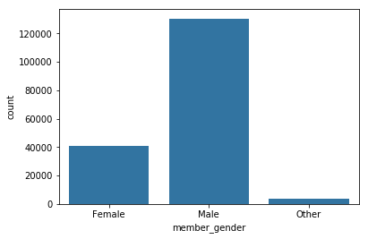

```python
sb.countplot(x='member_gender', data = df2, color=base_color);
```

There are more male riders in the dataset, followed by the female gender , then the other gender category

Next, taking a look at the **user type**

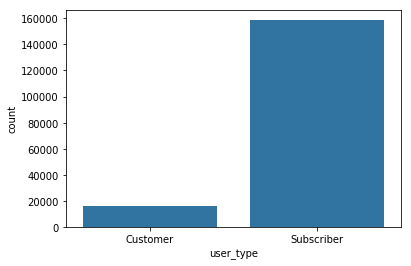

```python
sb.countplot(x='user_type', data = df2, color=base_color);
```

There are more subscibers than customers , there appears to be a very large difference

checking out the bike share for all trip

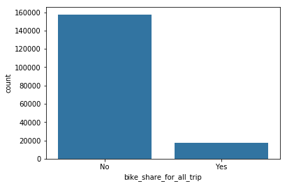

```python
sb.countplot(x='bike_share_for_all_trip', data = df2, color=base_color);
```

The Nos far outweigth the Yes in this instance

Next Up is to check the age distribution of the members in the dataset

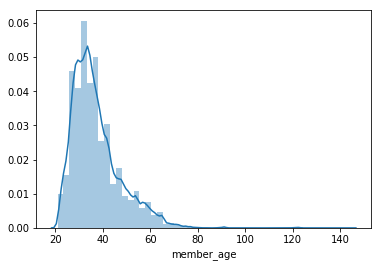

```python
sb.distplot(df3['member_age']);
```

There seems to be outliers in the dataset, there is a presence of a long tail after the 80 mark

```python
# To get raw stats in terms of numbers in the member age column
df3.member_age.describe()
```

```
count    174952.000000
mean         37.196865
std          10.118731
min          21.000000
25%          30.000000
50%          35.000000
75%          42.000000
max         144.000000
Name: member_age, dtype: float64
```

The maximum age as indicated here is age **144** from a 75th quantile age of 42, this requires further investigation

```python
df3.query('member_age >= 80').member_age.value_counts()
```

```
91.0     89
122.0    53
80.0     21
89.0     20
120.0    11
83.0     11
81.0      9
121.0     6
84.0      3
102.0     3
88.0      2
95.0      1
112.0     1
92.0      1
94.0      1
144.0     1
Name: member_age, dtype: int64
```

The dataset will now be reduced to contain only members with ages less than 80

```python
df5 = df4.query('member_age < 80')
```

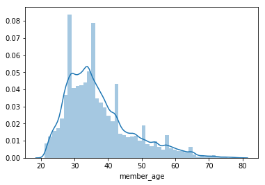

```python
sb.distplot(df5['member_age']);
```

Members between ages 25 and 35 are the majority in this dataset as clearly seen by the mode of the histogram above

Let's take a look at the distribution for the **duration of rides in seconds**

Taking a deeper look at the ages of users by

- Grouping the members into age groups
- Adding this age group as a new column

```python
# Age groups 21 to 35 as Young Adult, 35 to 60 as Middle age adults, 60 to 80 as Senior adults
age_range = [21,35,60,80]

age_range_name = ['young_adult', 'middle_age' , 'seniors']
```

```python
# code to create the age range column
df6 = df5.copy()
df6['age_range'] = pd.cut(df6['member_age'], bins=age_range, labels=age_range_name)
df6.head() # code to review changes
```

|  | duration_sec | start_time | end_time | start_station_name | end_station_name | bike_id | user_type | member_gender | bike_share_for_all_trip | member_age | age_range |
| --- | --- | --- | --- | --- | --- | --- | --- | --- | --- | --- | --- |
| 0 | 52185 | 2019-02-28 17:32:10.145 | 2019-03-01 08:01:55.975 | Montgomery St BART Station (Market St at 2nd St) | Commercial St at Montgomery St | 4902 | Customer | Male | No | 38.0 | middle_age |
| 2 | 61854 | 2019-02-28 12:13:13.218 | 2019-03-01 05:24:08.146 | Market St at Dolores St | Powell St BART Station (Market St at 4th St) | 5905 | Customer | Male | No | 50.0 | middle_age |
| 3 | 36490 | 2019-02-28 17:54:26.010 | 2019-03-01 04:02:36.842 | Grove St at Masonic Ave | Central Ave at Fell St | 6638 | Subscriber | Other | No | 33.0 | young_adult |
| 4 | 1585 | 2019-02-28 23:54:18.549 | 2019-03-01 00:20:44.074 | Frank H Ogawa Plaza | 10th Ave at E 15th St | 4898 | Subscriber | Male | Yes | 48.0 | middle_age |
| 5 | 1793 | 2019-02-28 23:49:58.632 | 2019-03-01 00:19:51.760 | 4th St at Mission Bay Blvd S | Broadway at Kearny | 5200 | Subscriber | Male | No | 63.0 | seniors |

Now to create a plot that shows the number of users in each age group

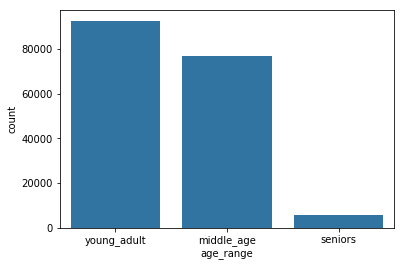

```python
sb.countplot(x='age_range', data = df6, color=base_color);
```

We have further established that young adults form the majority of users

Moving on to the duration of rides in seconds , plotting a histogram ti check for its distribution

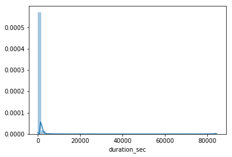

```python
sb.distplot(df6['duration_sec']);
```

As displayed above , there is a very long tail towards the 80000 seconds mark, these are could be outliers or just a result of the large diaparity in the values for duration of ride and it needs to be further investigated.

Most of the data is closer to zero than 20000

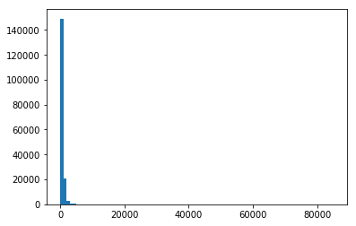

```python
# Using matplotlib to plot the distribution to enable manipulation of the plot freely
bin_size = 1000
bins = np.arange(0, df6['duration_sec'].max() + bin_size, bin_size )
plt.hist(data= df6, x= 'duration_sec', bins= bins);
```

The result is the same as that gotten with seaborn plot

```python
df6.duration_sec.describe()
```

```
count    174719.000000
mean        704.278338
std        1643.150058
min          61.000000
25%         323.000000
50%         511.000000
75%         789.000000
max       84548.000000
Name: duration_sec, dtype: float64
```

After looking at the durations in seconds values with statistical summary or description , the diaparity in the values can be spotted from the mean, standard deviation and the difference between the the 75% quantile and the max value.

This calls for the need to rescale these values, i'll be attempting this with the log scale

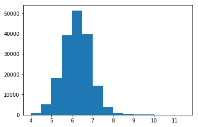

```python
bin_size = 0.5
bins = np.arange(4, np.log(df6['duration_sec']).max() + bin_size, bin_size )
plt.hist(np.log(df6['duration_sec']), bins= bins);
```

Simply applying the log Scale displays the Right Skewed Unimodal distribution that wasn't visible before

With Further tuning and cleaning , I can focus on the main distribution and cut out the outliers at the right tail

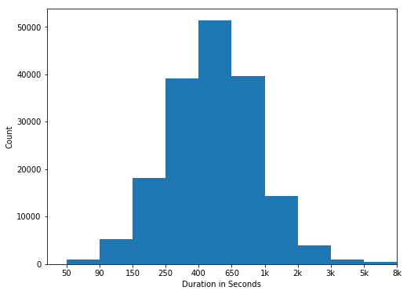

```python
plt.figure(figsize=(8, 6))
bin_size = 0.5
bins = np.arange(4, np.log(df6['duration_sec']).max() + bin_size, bin_size )
plt.hist(np.log(df6['duration_sec']), bins= bins);

# Setting the x ticks values and labels
x_ticks = list(bins)
plt.xticks(x_ticks,[50,90,150,250,400,650,'1k','2k','3k','5k','8k','13k','22k','36k','60k','98k'])

#Setting the x and y label
plt.xlabel('Duration in Seconds');
plt.ylabel('Count');

# Focus on the main part of the distribution and cutting out outliers
plt.xlim(3.7,9);
```

After all this processing it can be deduced that the mode lies within the 400 and 650 seconds range

### Discuss the distribution(s) of your variable(s) of interest. Were there any unusual points? Did you need to perform any transformations?

> The duration in seconds had a very range of values (the disparity in values i noted previously), so i had to perform a transformation ( rescaling ) with the log transform and it helped reveal the unimodal nature of the distribution

### Of the features you investigated, were there any unusual distributions? Did you perform any operations on the data to tidy, adjust, or change the form of the data? If so, why did you do this?

> The member age column also presented us with outliers , that i gladly cut out to help us focus on the main information. I also created a column of age groups to aid analysis

## Bivariate Exploration

> In this section, investigation of the relationships between pairs of variables in my data will be taking place.

Let's begin by exploring the relationship between duration of rides in seconds with member age

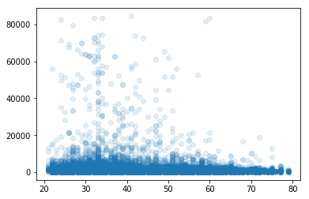

```python
plt.scatter(df6['member_age'], df6['duration_sec'], alpha=1/8);
```

The duration in seconds have to be rescaled using the log scale

[figure not shown]

```python
# Applying the log scale
plt.figure(figsize=[10,10])
plt.scatter(df6['member_age'], np.log(df6['duration_sec']), alpha=1/8);
# plt.yscale('log');

# Setting the x ticks values and labels
y_ticks = list(np.arange(4, np.log(df6['duration_sec']).max() + 0.5, 0.5 ))
plt.yticks(y_ticks,[50,90,150,250,400,650,'1k','2k','3k','5k','8k','13k','22k','36k','60k','98k']);

#Setting the x and y label
plt.xlabel('Duration in Seconds');
plt.ylabel('Age');

plt.title('Duration of rides and Age of Users');
```

The plot above shows that the younger adults take higher durations of rides

```python
# Making a copy of the dataset for further analysis
df7 = df6.copy()
# Making the data in the columns categorical
df6['age_range'] = pd.Categorical(df6['age_range'])
# To confirm the data type
df6['age_range'].dtype
```

```
CategoricalDtype(categories=['young_adult', 'middle_age', 'seniors'], ordered=True)
```

Let's explore the average duration in seconds of the various categorical data

Kicking off with the bike share for all trip

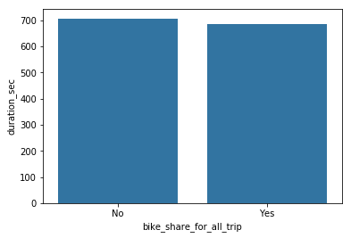

```python
sb.barplot(x='bike_share_for_all_trip', y='duration_sec', data=df7, color=base_color ,ci=None , estimator=mean);
```

Checking out the other categoricals at once

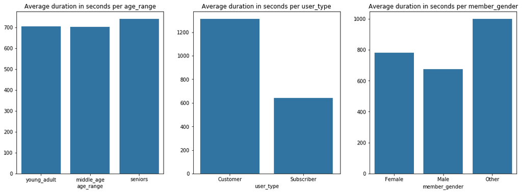

```python
# let's start with the major dimensions of the diamonds, with x, y, and z.

fig, ax = plt.subplots(ncols=3, figsize = [18,6])

variables = ['age_range' ,'user_type', 'member_gender']
for i in range(len(variables)):
    var = variables[i]

    sb.barplot(x=var, y='duration_sec', data=df7, color=base_color ,ci=None , estimator=mean, ax = ax[i])
    ax[i].set_xlabel('{}'.format(var))
    ax[i].set_ylabel('')
    ax[i].set_title('Average duration in seconds per {}'.format(var))

plt.show();
```

The following can be deduced by the visuals above

- Senior Adults havea higher duration of rides on average than the other age group despite have the smallest range of ride duration
- Customers have higher ride durations than subscribers
- The `other` group of member gender have the highest average ride duration,

I feel the need to further investigate using boxplot , to try and get a deeper understanding of what is going on

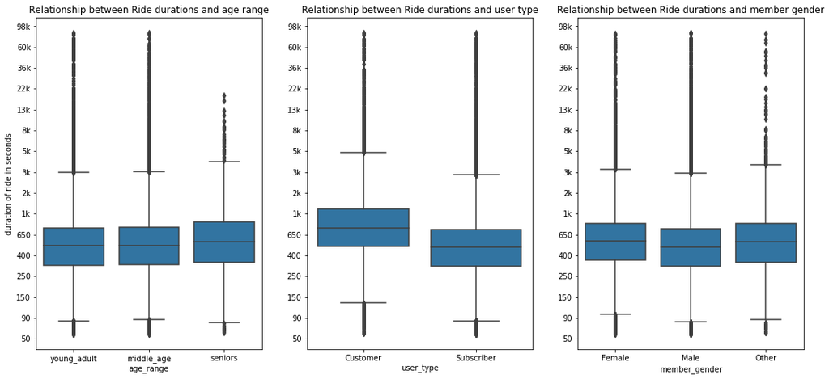

```python
# let's start with the major dimensions of the diamonds, with x, y, and z.

fig, ax = plt.subplots(ncols=3, figsize = [18,8])

variables = ['age_range' ,'user_type', 'member_gender']
for i in range(len(variables)):
    var = variables[i]

    sb.boxplot(x=var, y=np.log(df7['duration_sec']), data=df6, color=base_color , ax = ax[i])
    ax[i].set_xlabel('{}'.format(var))
    ax[i].set_ylabel('')


    ax[i].set_yticks(np.arange(4, np.log(df7['duration_sec']).max() + 0.5, 0.5 ))
    ax[i].set_yticklabels([50,90,150,250,400,650,'1k','2k','3k','5k','8k','13k','22k','36k','60k','98k'])

    ax[i].set_title('Relationship between Ride durations and {}'.format(var.split('_')[0] + ' ' + var.split('_')[1]))

ax[0].set_ylabel('duration of ride in seconds')
plt.show();
```

The boxplots for age range and user type are consistent with that of the bar chat, but we can now get a better look at the genders of the users

- Firstly, the male gender still has the lowest average ride duration
- It can be seen that the modes of the three genders are really close , with female and other being almost equal
- The difference comes from the confidence interval with "other" having a larger confidence level

### Talk about some of the relationships you observed in this part of the investigation. How did the feature(s) of interest vary with other features in the dataset?

> The range of ride durations decrease with increase in age of users (that is going from young adults to seniors)

## Multivariate Exploration

> Creation of plots with three or more variables to investigate my data even further.

```python
df8 = df7.copy()
```

Starting with the relationship between the age range , gender of users and ride duration

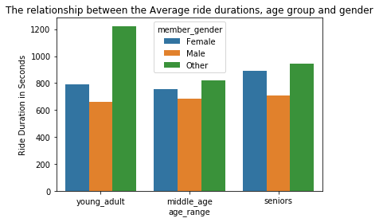

```python
sb.barplot(x='age_range', y='duration_sec', hue='member_gender', ci=None, data=df8);
plt.ylabel('Ride Duration in Seconds')
plt.title('The relationship between the Average ride durations, age group and gender');
```

The plot in the above visual follows the trend we have been seeing except with the "other" gender type

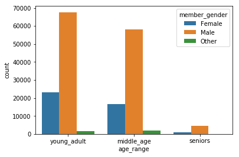

```python
# A plot to inspect the ratio of the different genders in each age group
sb.countplot(x='age_range', hue='member_gender', data=df8);
```

After further investigation using the bivariate visual above , this could be as a result of there not being significant number of "other" gender in the seniors age group

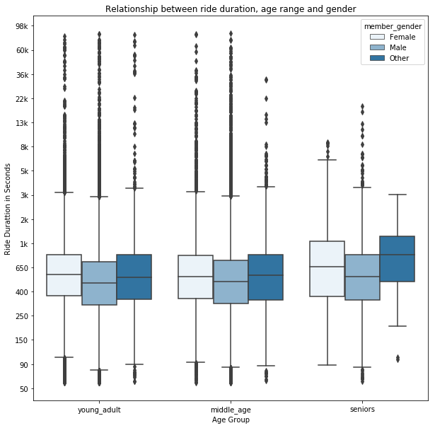

```python
plt.figure(figsize=[10,10])
sb.boxplot(x='age_range', y=np.log(df7['duration_sec']), hue = 'member_gender', data=df8, color=base_color)
# Setting the x ticks values and labels
y_ticks = list(np.arange(4, np.log(df8['duration_sec']).max() + 0.5, 0.5 ))
plt.yticks(y_ticks,[50,90,150,250,400,650,'1k','2k','3k','5k','8k','13k','22k','36k','60k','98k']);

#Setting the x and y label
plt.xlabel('Age Group');
plt.ylabel('Ride Durattion in Seconds');

plt.title('Relationship between ride duration, age range and gender');
```

Again a box plot tells the true story

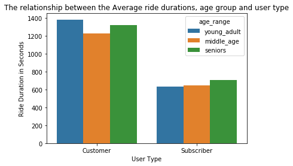

```python
sb.barplot(x='user_type', y='duration_sec', hue='age_range', ci=None, data=df8);
plt.xlabel('User Type');
plt.ylabel('Ride Duration in Seconds')
plt.title('The relationship between the Average ride durations, age group and user type');
```

From the plot above it can be seen that

### Talk about some of the relationships you observed in this part of the investigation. Were there features that strengthened each other in terms of looking at your feature(s) of interest?

> The box plot helped in further burtressing the point that Senior adult have longer ride durations than the younger adults and this trend was throughout the various gender

## Conclusions

### Limitations

The dataset covers only the month of february , I believe it would have being more insightful to use data that covers a whole year